# Big Data White Paper Data Visualization

Exploring minimum wage data. Unemployment rate vs state minimum wage in selected states.

**Sources:**

- FRED: Unemployment rate Texas: https://fred.stlouisfed.org/series/TXUR
- FRED: Unemployment rate California: https://fred.stlouisfed.org/series/CAUR
- FRED: Unemployment rate Vermont: https://fred.stlouisfed.org/series/VTUR
- FRED: Unemployment rate Wisconsin: https://fred.stlouisfed.org/series/WIUR
- FRED: Minimum Wage TEXAS: https://fred.stlouisfed.org/series/STTMINWGTX
- FRED: Minimum Wage California: https://fred.stlouisfed.org/series/STTMINWGCA
- FRED: Minimum Wage Vermont: https://fred.stlouisfed.org/series/STTMINWGVT
- FRED: Minimum Wage Wisconsin: https://fred.stlouisfed.org/series/STTMINWGWI

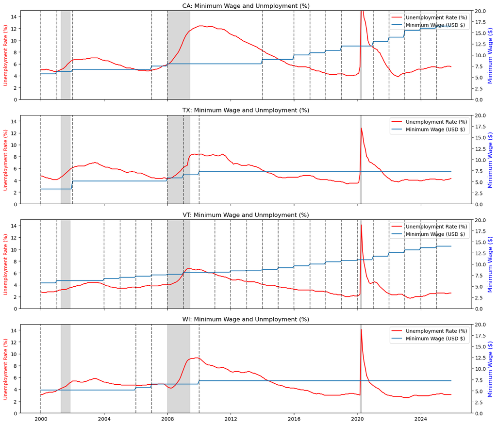

For this preliminary visual analysis, I pulled historical data from FRED using Pandas Datareader to compare minimum wage trends against unemployment rates in a few select states from 2000 to today, with two acting as the 'research group' and two acting as the 'control.'

I chose California and Texas because they are two states of similar population and one high minimum wage, while the other at the federal minimum. However, it is important to note that the cost of living between these states is very different. In future visulization that would need to be taken into account, or more states used to reduce that effect. Vermont is where I am from with a high minimum wage (14.42) and Wisonsin is where I live now minimum (7.25). Four very different states could help us uncover ideas and trends.

I had to clean it by dropping missing values and forward-filling the minimum wage data so it correctly reflects the wage until the next scheduled increase. The resulting charts use a two y-axis with standardized scaling to keep comparisons between states fair and clear.

I also added grey recession bars and dashed vertical lines at every wage hike to provide important context. This allows us to see how unemployment spikes are largely driven by broader economic trends rather than being immediately triggered by state-level policy changes. Overall, it highlights that while minimum wage paths have diverged significantly between these 4 states, their unemployment remains tied to the same national macro economic shocks.